# QK Box 16.2

### Worked example of NMDS, ANOSIM, PERMANOVA, MV-ABUND, BIO-ENV: invertebrates in artificial ponds

We continue with the pond invertebrate example from Box 16.1. We will now use these data to produce an NMDS ordination plot showing the relationship among ponds based on invertebrate family abundances. We will compare this analysis to one where the abundances are converted to proportions of pond totals and where abundances are converted to presence-absence data. We will also compare the four management groups using ANOSIM, PERMANOVA, and MV-ABUND and examine relationships between the patterns among ponds based on invertebrate families and patterns based on environmental variables.

### Preliminaries

Load graphics tweaks and core set of packages

Load additional packages: vegan, mvabund

Load lemminvert data and remove labels

```r
lemminvert <- read_csv("../data/lemminvert.csv")
```

```r
lemminvert1 <- lemminvert[,-(1:3)]
```

### MDS on original invert abundances

```r
lemminvert.bc <- vegdist(lemminvert1,'bray')    #Create Bray-Curtis matrix
lemminvert.mds <- metaMDS(lemminvert.bc,k=2,autotransform=FALSE)
```

```
*** Best solution repeated 3 times
```

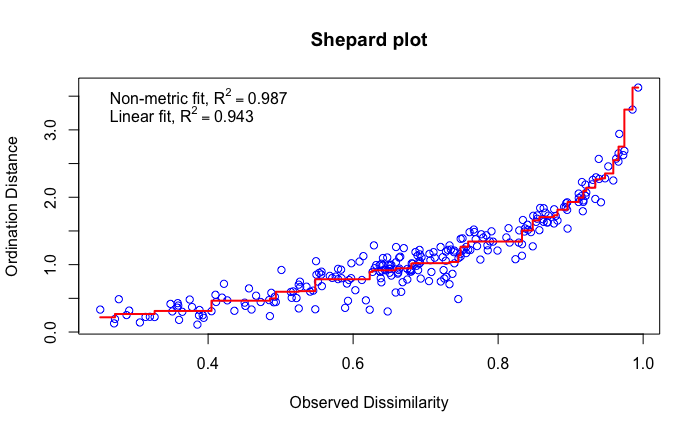

```r
stressplot(lemminvert.mds, main="Shepard plot")
```

```r
lemminvert.mds
```

```
Call:
metaMDS(comm = lemminvert.bc, k = 2, autotransform = FALSE)

global Multidimensional Scaling using monoMDS

Data:     lemminvert.bc
Distance: bray

Dimensions: 2
Stress:     0.1153228735
Stress type 1, weak ties
Best solution was repeated 3 times in 20 tries
The best solution was from try 14 (random start)
Scaling: centring, PC rotation, halfchange scaling
Species: scores missing
```

```r
plot(lemminvert.mds$points,type="n")
text(lemminvert.mds$points,lab=lemminvert$manag,col="black")
```

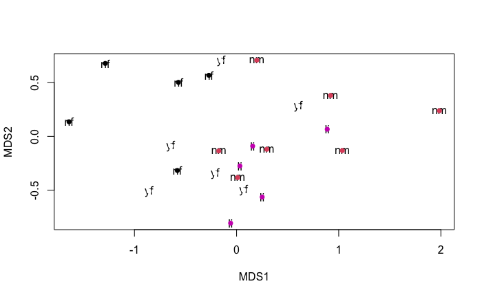

```r
points(lemminvert.mds$points,pch=16,col=as.numeric(lemminvert$managsymb))
```

### Standardize abundance to proportional abundance for each pond

```r
lemminvert1s <- decostand(lemminvert1, method = "total")
lemminvert1s.bc <- vegdist(lemminvert1s,'bray')
lemminvert1s.mds <- metaMDS(lemminvert1s.bc,k=2,try=20,trymax=40,maxit=200,autotransform=FALSE)
```

```
*** Best solution repeated 1 times
```

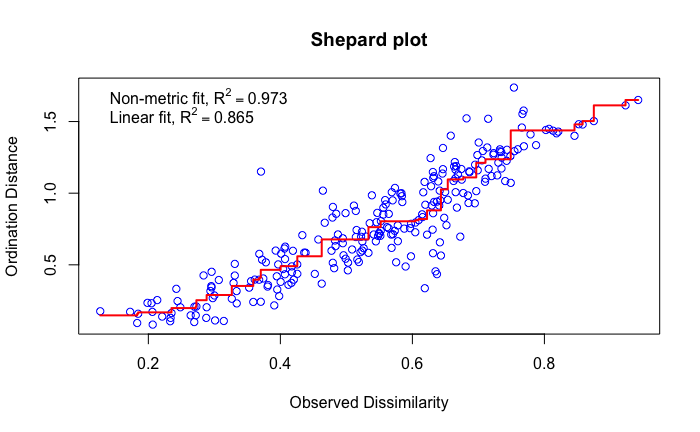

```r
stressplot(lemminvert1s.mds, main="Shepard plot")
```

```r
lemminvert1s.mds
```

```
Call:
metaMDS(comm = lemminvert1s.bc, k = 2, try = 20, trymax = 40,      autotransform = FALSE, maxit = 200)

global Multidimensional Scaling using monoMDS

Data:     lemminvert1s.bc
Distance: bray

Dimensions: 2
Stress:     0.1648801129
Stress type 1, weak ties
Best solution was repeated 1 time in 20 tries
The best solution was from try 15 (random start)
Scaling: centring, PC rotation, halfchange scaling
Species: scores missing
```

```r
plot(lemminvert1s.mds$points,type="n")
text(lemminvert1s.mds$points,lab=lemminvert$manag,col="black")
```

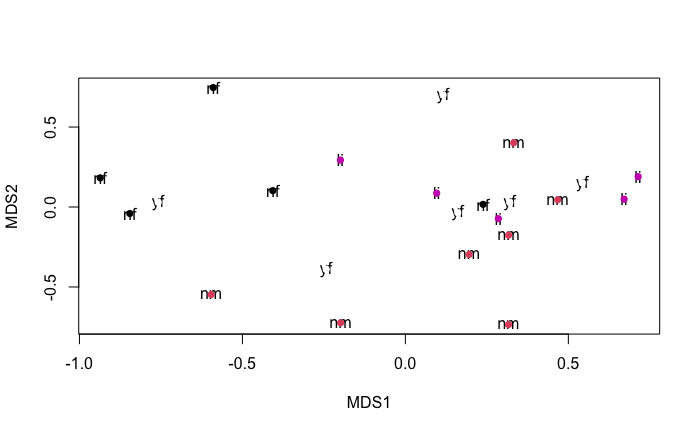

```r
points(lemminvert1s.mds$points,pch=16,col=as.numeric(lemminvert$managsymb))
```

### MDS on presence-absence using Jaccard transformed data

```r
lemminvert.jac <- vegdist(lemminvert1,binary=TRUE,method='jaccard')
lemminvert.jac.mds <- metaMDS(lemminvert.jac,k=2,autotransform=FALSE)
```

```
*** Best solution repeated 3 times
```

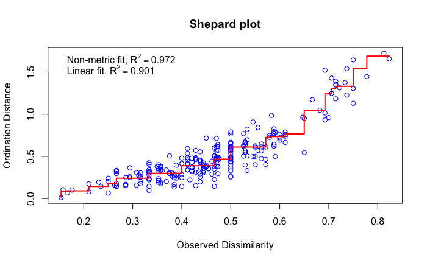

```r
stressplot(lemminvert.jac.mds, main="Shepard plot")
```

```r
lemminvert.jac.mds
```

```
Call:
metaMDS(comm = lemminvert.jac, k = 2, autotransform = FALSE)

global Multidimensional Scaling using monoMDS

Data:     lemminvert.jac
Distance: binary jaccard

Dimensions: 2
Stress:     0.1676823497
Stress type 1, weak ties
Best solution was repeated 3 times in 20 tries
The best solution was from try 18 (random start)
Scaling: centring, PC rotation, halfchange scaling
Species: scores missing
```

```r
plot(lemminvert.jac.mds$points,type="n")
text(lemminvert.jac.mds$points,lab=lemminvert$manag,col="black")
```

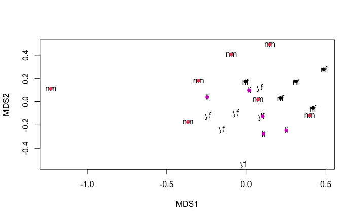

```r
points(lemminvert.jac.mds$points,pch=16,col=as.numeric(lemminvert$managsymb))
```

### Plot env variables on ordinations

Select 11 variables (same as ch15)

```r
lemmenv <- read_csv("../data/lemmenv.csv")
lemmenv1 <- lemmenv[,c(3:5,7:8,10:13,16:17)]
# standardize predictors
lemmenv1$lchla <- log10(lemmenv1$chla)
lemmenv1$depth <- scale(lemmenv1$depth)
lemmenv1$silt <- scale(lemmenv1$silt)
lemmenv1$ph <- scale(lemmenv1$ph)
lemmenv1$temp <- scale(lemmenv1$temp)
lemmenv1$surface <- scale(lemmenv1$surface)
lemmenv1$cond <- scale(lemmenv1$cond)
lemmenv1$lchla <- scale(lemmenv1$lchla)
lemmenv1$tn <- scale(lemmenv1$tn)
lemmenv1$tp <- scale(lemmenv1$tp)
lemmenv1$reed <- scale(lemmenv1$reed)
lemmenv1$emerg <- scale(lemmenv1$emerg)
# plot using original abundances
fit1 <- envfit(lemminvert.mds, lemmenv1)
fit1
```

```
***VECTORS

              NMDS1       NMDS2      r2 Pr(>r)
depth    0.04741568 -0.99887524 0.17443  0.165
silt     0.86935396  0.49418993 0.12897  0.253
ph       0.29031669 -0.95693062 0.12645  0.254
temp    -0.16690777 -0.98597251 0.00161  0.989
surface  0.01868586 -0.99982540 0.21044  0.093 .
cond    -0.19972348 -0.97985230 0.08807  0.395
chla     0.59035813 -0.80714143 0.08145  0.441
tn      -0.49295639 -0.87005402 0.19845  0.123
tp      -0.36943509 -0.92925654 0.34857  0.021 *
reed    -0.67318080  0.73947793 0.21728  0.074 .
emerg   -0.62429867  0.78118574 0.12491  0.247
lchla    0.15594189 -0.98776623 0.15798  0.185
---
Signif. codes:  0 ‘***’ 0.001 ‘**’ 0.01 ‘*’ 0.05 ‘.’ 0.1 ‘ ’ 1
Permutation: free
Number of permutations: 999
```

```r
plot(fit1)
```

```
Error in strwidth(labels, ...) : plot.new has not been called yet
```

```r
# plot using proportional abundances
fit2 <- envfit(lemminvert1s.mds, lemmenv1)
fit2
```

```
***VECTORS

              NMDS1       NMDS2      r2 Pr(>r)
depth    0.97880991 -0.20477100 0.15296  0.215
silt    -0.10984606 -0.99394861 0.02816  0.755
ph       0.94740555  0.32003550 0.08464  0.365
temp     0.20178633 -0.97942957 0.02851  0.757
surface  0.86028323 -0.50981641 0.13431  0.235
cond     0.46289026 -0.88641559 0.08084  0.420
chla     0.64367295  0.76530068 0.02808  0.738
tn       0.33297260  0.94293650 0.15821  0.170
tp       0.57503048  0.81813198 0.14516  0.217
reed    -0.70398668  0.71021318 0.26945  0.047 *
emerg   -0.79831881  0.60223507 0.15104  0.217
lchla    0.98631286  0.16488465 0.11665  0.293
---
Signif. codes:  0 ‘***’ 0.001 ‘**’ 0.01 ‘*’ 0.05 ‘.’ 0.1 ‘ ’ 1
Permutation: free
Number of permutations: 999
```

```r
plot(fit2)
```

```
Error in strwidth(labels, ...) : plot.new has not been called yet
```

```r
# plot using pa
fit3 <- envfit(lemminvert.jac.mds, lemmenv1)
fit3
```

```
***VECTORS

              NMDS1       NMDS2      r2 Pr(>r)
depth   -0.67142734 -0.74107039 0.02419  0.793
silt    -0.81534590 -0.57897415 0.00657  0.924
ph       0.05623164 -0.99841775 0.04591  0.620
temp     0.56637607 -0.82414692 0.03547  0.702
surface -0.01819445 -0.99983447 0.06929  0.498
cond    -0.07848917 -0.99691497 0.05734  0.567
chla     0.11334636 -0.99355554 0.01579  0.832
tn       0.10793391 -0.99415807 0.04332  0.645
tp       0.23971575 -0.97084312 0.10234  0.333
reed     0.36892078 -0.92946084 0.06170  0.550
emerg    0.89227883  0.45148475 0.19596  0.110
lchla    0.43900893 -0.89848270 0.01533  0.849
Permutation: free
Number of permutations: 999
```

```r
plot(fit3)
```

```
Error in strwidth(labels, ...) : plot.new has not been called yet
```

### Model/test management types

Check homogeneity of dispersions on original abundances; if OK, for comparison run anosim, permanova and mvabund

```r
lemminvert.disp <- betadisper(lemminvert.bc,lemminvert$manag)
anova(lemminvert.disp)
```

```
Analysis of Variance Table

Response: Distances
          Df     Sum Sq     Mean Sq F value Pr(>F)
Groups     3 0.05364661 0.017882203 1.06078  0.389
Residuals 19 0.32029544 0.016857655
```

```r
# anosim on original abundances
lemminvert.ano <- anosim(lemminvert.bc, lemminvert$manag,permutations=999)
summary(lemminvert.ano)
```

```
Call:
anosim(x = lemminvert.bc, grouping = lemminvert$manag, permutations = 999)
Dissimilarity: bray

ANOSIM statistic R: 0.1729514
      Significance: 0.017

Permutation: free
Number of permutations: 999

Upper quantiles of permutations (null model):
   90%    95%  97.5%    99%
0.0953 0.1275 0.1502 0.1828

Dissimilarity ranks between and within classes:
        0%   25%   50%    75% 100%   N
Between  1 68.00 133.0 200.00  253 197
li      10 15.75  43.5 105.50  181  10
nf      34 93.00 127.0 151.75  193  10
nm      25 64.00 132.0 177.00  236  21
yf       6 67.50  85.0 163.00  195  15
```

```r
# permanova on original abundances
lemminvert.ado <- adonis2(lemminvert.bc~manag,data=lemminvert,permutations=999)
print(lemminvert.ado)
```

```
Permutation test for adonis under reduced model
Terms added sequentially (first to last)
Permutation: free
Number of permutations: 999

adonis2(formula = lemminvert.bc ~ manag, data = lemminvert, permutations = 999)
         Df  SumOfSqs         R2       F Pr(>F)
manag     3 1.3565598 0.25111301 2.12366  0.007 **
Residual 19 4.0456287 0.74888699
Total    22 5.4021885 1.00000000
---
Signif. codes:  0 ‘***’ 0.001 ‘**’ 0.01 ‘*’ 0.05 ‘.’ 0.1 ‘ ’ 1
```

```r
# mv-abund on original abundances
lemminvertmv <- mvabund(lemminvert1)
lemminvertmv.mv <- manyglm(lemminvertmv~lemmenv$manag,family="negative_binomial")
plot(lemminvertmv.mv)
anova(lemminvertmv.mv)
```

[output not shown]

Repeat process for proportional abundance data

```r
# check homog of dispersions on prop abundances
lemminvert1s.disp <- betadisper(lemminvert1s.bc,lemminvert$manag)
anova(lemminvert1s.disp)
```

```
Analysis of Variance Table

Response: Distances
          Df     Sum Sq      Mean Sq F value  Pr(>F)
Groups     3 0.02873894 0.0095796473 0.51922 0.67413
Residuals 19 0.35055280 0.0184501474
```

```r
# anosim on proportional abundances
lemminvert1s.ano <- anosim(lemminvert1s.bc, lemminvert$manag,permutations=999)
summary(lemminvert1s.ano)
```

```
Call:
anosim(x = lemminvert1s.bc, grouping = lemminvert$manag, permutations = 999)
Dissimilarity: bray

ANOSIM statistic R: 0.117839
      Significance: 0.062

Permutation: free
Number of permutations: 999

Upper quantiles of permutations (null model):
   90%    95%  97.5%    99%
0.0906 0.1278 0.1474 0.1847

Dissimilarity ranks between and within classes:
        0%   25%   50%    75% 100%   N
Between  1  63.0 132.0 200.00  253 197
li      15  46.0  65.5  81.75  159  10
nf      42  88.0 102.5 186.75  191  10
nm       7  83.0 149.0 173.00  240  21
yf       2 104.5 123.0 161.00  236  15
```

```r
# permanova on proportional abundances
lemminvert1s.ado <- adonis2(lemminvert1s.bc~manag,data=lemminvert,permutations=999)
print(lemminvert1s.ado)
```

```
Permutation test for adonis under reduced model
Terms added sequentially (first to last)
Permutation: free
Number of permutations: 999

adonis2(formula = lemminvert1s.bc ~ manag, data = lemminvert, permutations = 999)
         Df  SumOfSqs         R2       F Pr(>F)
manag     3 0.8296405 0.23689983 1.96614  0.035 *
Residual 19 2.6724326 0.76310017
Total    22 3.5020732 1.00000000
---
Signif. codes:  0 ‘***’ 0.001 ‘**’ 0.01 ‘*’ 0.05 ‘.’ 0.1 ‘ ’ 1
```

mv-abund on proportional abundances using composition=TRUE (this either doesnt work or is very slow!!!) Note: when composition=TRUE, gives error message; runs with composition=FALSE, but that isn’t relative abundance

```r
lemminvert1smv.mv <- manyglm(lemminvertmv~lemmenv$manag,composition=TRUE,family="negative_binomial")
```

```
Error in manyglm(lemminvertmv ~ lemmenv$manag, composition = TRUE, family = "negative_binomial") :
  object '"negative_binomial"' not found
```

[figure not shown]

```r
plot(lemminvert1smv.mv)
```

```r
anova(lemminvert1smv.mv)
```

[output not shown]

try mv-abund on standardized abunds from earlier

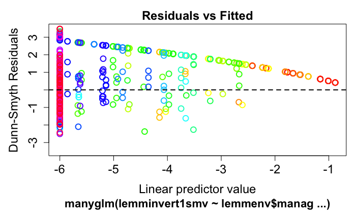

```r
lemminvert1smv <- mvabund(lemminvert1s)
lemminvert1smv.mv <- manyglm(lemminvert1smv~lemmenv$manag,family="negative_binomial")
plot(lemminvert1smv.mv)
```

```r
anova(lemminvert1smv.mv)
```

```
Time elapsed: 0 hr 0 min 1 sec
Analysis of Deviance Table

Model: lemminvert1smv ~ lemmenv$manag

Multivariate test:
              Res.Df Df.diff    Dev Pr(>Dev)
(Intercept)       22
lemmenv$manag     19       3 8.3276    0.001 ***
---
Signif. codes:  0 ‘***’ 0.001 ‘**’ 0.01 ‘*’ 0.05 ‘.’ 0.1 ‘ ’ 1
Arguments:
 Test statistics calculated assuming uncorrelated response (for faster computation)
 P-value calculated using 999 iterations via PIT-trap resampling.
```

Finally, run analysis on presence-absence data

```r
# check homog of dispersions on pa
lemminvert.jac.disp <- betadisper(lemminvert.jac,lemminvert$manag)
anova(lemminvert.jac.disp)
```

```
Analysis of Variance Table

Response: Distances
          Df      Sum Sq      Mean Sq F value  Pr(>F)
Groups     3 0.058952285 0.0196507616  2.1726 0.12472
Residuals 19 0.171851500 0.0090448158
```

```r
# anosim on pa
lemminvert.jac.ano <- anosim(lemminvert.jac, lemminvert$manag,permutations=999)
summary(lemminvert.jac.ano)
```

```
Call:
anosim(x = lemminvert.jac, grouping = lemminvert$manag, permutations = 999)
Dissimilarity: binary jaccard

ANOSIM statistic R: 0.1024293
      Significance: 0.074

Permutation: free
Number of permutations: 999

Upper quantiles of permutations (null model):
   90%    95%  97.5%    99%
0.0905 0.1205 0.1445 0.1833

Dissimilarity ranks between and within classes:
          0%     25%    50%     75%  100%   N
Between  1.0  72.000 131.50 186.500 253.0 197
li      21.5  53.250  72.75 113.125 204.5  10
nf       5.5  34.625  66.00 100.500 219.5  10
nm      41.0 117.000 195.50 230.500 249.0  21
yf      21.5  41.000  72.00 128.250 192.5  15
```

```r
# permanova on pa
lemminvert.jac.ado <- adonis2(lemminvert.jac~manag,data=lemminvert,permutations=999)
print(lemminvert.jac.ado)
```

```
Permutation test for adonis under reduced model
Terms added sequentially (first to last)
Permutation: free
Number of permutations: 999

adonis2(formula = lemminvert.jac ~ manag, data = lemminvert, permutations = 999)
         Df   SumOfSqs         R2       F Pr(>F)
manag     3 0.54394094 0.21570186 1.74183  0.008 **
Residual 19 1.97778484 0.78429814
Total    22 2.52172579 1.00000000
---
Signif. codes:  0 ‘***’ 0.001 ‘**’ 0.01 ‘*’ 0.05 ‘.’ 0.1 ‘ ’ 1
```

mv-abund on pa

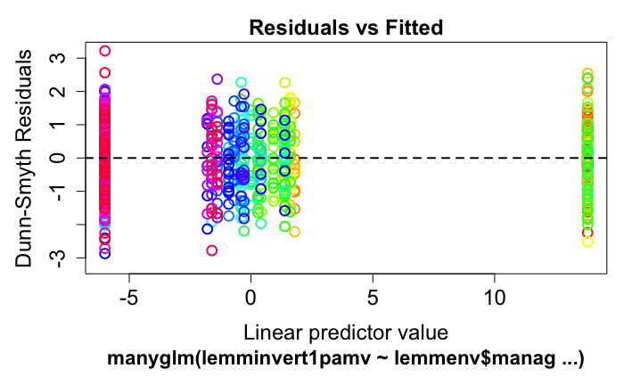

```r
lemminvert1pa <- decostand(lemminvert1, method = "pa")
lemminvert1pamv <- mvabund(lemminvert1pa)
lemminvert1pamv.mv <- manyglm(lemminvert1pamv~lemmenv$manag,family="binomial")
plot(lemminvert1pamv.mv)
```

```r
anova(lemminvert1pamv.mv)
```

```
Time elapsed: 0 hr 0 min 1 sec
Analysis of Deviance Table

Model: lemminvert1pamv ~ lemmenv$manag

Multivariate test:
              Res.Df Df.diff     Dev Pr(>Dev)
(Intercept)       22
lemmenv$manag     19       3 127.529    0.034 *
---
Signif. codes:  0 ‘***’ 0.001 ‘**’ 0.01 ‘*’ 0.05 ‘.’ 0.1 ‘ ’ 1
Arguments:
 Test statistics calculated assuming uncorrelated response (for faster computation)
 P-value calculated using 999 iterations via PIT-trap resampling.
```

### Use bio-env to explore relationships with environmental variables

```r
# bio-env raw data
bioenv(lemminvert.bc, lemmenv1, method="spearman", metric="euclidean")
```

```
4095 possible subsets (this may take time...)

Call:
bioenv(comm = lemminvert.bc, env = lemmenv1, method = "spearman",      metric = "euclidean")

Subset of environmental variables with best correlation to community data.

Correlations:    spearman
Dissimilarities: bray
Metric:          euclidean

Best model has 3 parameters (max. 12 allowed):
depth tp emerg
with correlation  0.1053499931
```

```r
# bio-env prop data
bioenv(lemminvert1s.bc, lemmenv1,method="spearman", metric="euclidean")
```

```
4095 possible subsets (this may take time...)

Call:
bioenv(comm = lemminvert1s.bc, env = lemmenv1, method = "spearman",      metric = "euclidean")

Subset of environmental variables with best correlation to community data.

Correlations:    spearman
Dissimilarities: bray
Metric:          euclidean

Best model has 3 parameters (max. 12 allowed):
depth emerg lchla
with correlation  0.1969941504
```

```r
# bio-env on pa data
bioenv(lemminvert.jac, lemmenv1,method="spearman", metric="euclidean")
```

```
4095 possible subsets (this may take time...)

Call:
bioenv(comm = lemminvert.jac, env = lemmenv1, method = "spearman",      metric = "euclidean")

Subset of environmental variables with best correlation to community data.

Correlations:    spearman
Dissimilarities: binary jaccard
Metric:          euclidean

Best model has 4 parameters (max. 12 allowed):
surface tp reed emerg
with correlation  0.0649229655
```

```r
# mantel test
lemmenv.euc <- vegdist(lemmenv1,"euclidean")
mantel(lemminvert.bc,lemmenv.euc,method="spearman")
```

```
Mantel statistic based on Spearman's rank correlation rho

Call:
mantel(xdis = lemminvert.bc, ydis = lemmenv.euc, method = "spearman")

Mantel statistic r: -0.04405329
      Significance: 0.562

Upper quantiles of permutations (null model):
  90%   95% 97.5%   99%
0.169 0.234 0.278 0.328
Permutation: free
Number of permutations: 999
```

```r
mantel(lemminvert.bc,lemmenv.euc,method="pearson")
```

```
Mantel statistic based on Pearson's product-moment correlation

Call:
mantel(xdis = lemminvert.bc, ydis = lemmenv.euc, method = "pearson")

Mantel statistic r: -0.01516855
      Significance: 0.49

Upper quantiles of permutations (null model):
  90%   95% 97.5%   99%
0.212 0.274 0.324 0.392
Permutation: free
Number of permutations: 999
```

### model/test continuous variables with permanova and mv-abund

```r
# raw abundances
lemminvert2.ado <- adonis2(lemminvert.bc~depth+silt+ph+temp+surface+cond+lchla+tn+tp+reed+emerg,data=lemmenv1,permutations=999)
print(lemminvert2.ado)
```

```
Permutation test for adonis under reduced model
Terms added sequentially (first to last)
Permutation: free
Number of permutations: 999

adonis2(formula = lemminvert.bc ~ depth + silt + ph + temp + surface + cond + lchla + tn + tp + reed + emerg, data = lemmenv1, permutations = 999)
         Df  SumOfSqs         R2       F Pr(>F)
depth     1 0.3151774 0.05834254 1.46650  0.193
silt      1 0.3977300 0.07362387 1.85061  0.071 .
ph        1 0.2925690 0.05415750 1.36130  0.192
temp      1 0.2549017 0.04718489 1.18604  0.296
surface   1 0.2704965 0.05007165 1.25860  0.277
cond      1 0.1157972 0.02143524 0.53880  0.834
lchla     1 0.2177099 0.04030031 1.01299  0.429
tn        1 0.2588641 0.04791838 1.20448  0.298
tp        1 0.2439905 0.04516512 1.13527  0.323
reed      1 0.2886512 0.05343227 1.34307  0.230
emerg     1 0.3821963 0.07074842 1.77833  0.090 .
Residual 11 2.3641047 0.43761981
Total    22 5.4021885 1.00000000
---
Signif. codes:  0 ‘***’ 0.001 ‘**’ 0.01 ‘*’ 0.05 ‘.’ 0.1 ‘ ’ 1
```

```r
lemminvert3.ado <- adonis2(lemminvert.bc~depth+silt+ph+temp+surface+cond+lchla+tn+tp+reed+emerg,data=lemmenv1,by="margin",permutations=999)
print(lemminvert3.ado)
```

```
Permutation test for adonis under reduced model
Marginal effects of terms
Permutation: free
Number of permutations: 999

adonis2(formula = lemminvert.bc ~ depth + silt + ph + temp + surface + cond + lchla + tn + tp + reed + emerg, data = lemmenv1, permutations = 999, by = "margin")
         Df  SumOfSqs         R2       F Pr(>F)
depth     1 0.3294949 0.06099286 1.53311  0.147
silt      1 0.1810559 0.03351528 0.84244  0.569
ph        1 0.2562631 0.04743690 1.19237  0.274
temp      1 0.2256969 0.04177879 1.05015  0.366
surface   1 0.2482610 0.04595563 1.15514  0.327
cond      1 0.0572557 0.01059861 0.26641  0.991
lchla     1 0.3096201 0.05731384 1.44064  0.166
tn        1 0.1236755 0.02289360 0.57545  0.814
tp        1 0.3417611 0.06326345 1.59019  0.134
reed      1 0.2324913 0.04303650 1.08176  0.345
emerg     1 0.3821963 0.07074842 1.77833  0.084 .
Residual 11 2.3641047 0.43761981
Total    22 5.4021885 1.00000000
---
Signif. codes:  0 ‘***’ 0.001 ‘**’ 0.01 ‘*’ 0.05 ‘.’ 0.1 ‘ ’ 1
```

```r
lemminvertmv <- mvabund(lemminvert1)
lemminvertmv.mv <- manyglm(lemminvertmv~lemmenv1$depth+lemmenv1$silt+lemmenv1$ph+lemmenv1$temp+lemmenv1$surface+lemmenv1$cond+lemmenv1$lchla+lemmenv1$tn+lemmenv1$tp+lemmenv1$reed+lemmenv1$emerg,family="negative_binomial")
# use summary to get Wald tests (at least vaguely comparable to Type III Permanova results)
summary(lemminvertmv.mv)
```

```
Test statistics:
                 wald value Pr(>wald)
(Intercept)        52.51585     0.009 **
lemmenv1$depth      6.18052     0.376
lemmenv1$silt       6.81522     0.268
lemmenv1$ph         6.41864     0.364
lemmenv1$temp       6.45409     0.364
lemmenv1$surface    7.05475     0.262
lemmenv1$cond       4.69355     0.786
lemmenv1$lchla      7.41865     0.219
lemmenv1$tn         5.29815     0.635
lemmenv1$tp         6.96154     0.311
lemmenv1$reed       6.07868     0.518
lemmenv1$emerg      5.45911     0.615
---
Signif. codes:  0 ‘***’ 0.001 ‘**’ 0.01 ‘*’ 0.05 ‘.’ 0.1 ‘ ’ 1

Test statistic:  28.80876, p-value: 0.111
Arguments:
 Test statistics calculated assuming response assumed to be uncorrelated
 P-value calculated using 999 resampling iterations via pit.trap resampling (to account for correlation in testing).
```

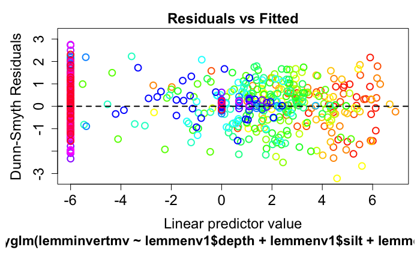

```r
plot(lemminvertmv.mv)
```

### Generate graphs

```r
br=c("nm","li","nf","yf")
la=c("None", "Light", "No fish", "Young fish")
a<-as.data.frame(lemminvert.mds$points)
a<-cbind(lemminvert[c(1:3)],a)   #Add site names & symbols from original data file
p1<-ggplot(data=a, aes(x=MDS1, y=MDS2, shape=manag, ) )+
  geom_point()+
  labs(y="MDS2", x="MDS1", title="Raw")+
  scale_shape_manual(values=sym4,
                     name="Management",
                     breaks=br,
                     labels=la,
                     guide =
                         guide_legend(label.theme = element_text(size=6),
                                    title=NULL)
                     )+
  theme_qk()
as<-as.data.frame(lemminvert1s.mds$points)
as<-cbind(lemminvert[c(1:3)],as)   #Add site names & symbols from original data file
p2<-ggplot(data=as, aes(x=MDS1, y=MDS2, shape=manag, ) )+
  geom_point()+
  labs(y=NULL, x="MDS1", title="Standardized")+
  scale_shape_manual(values=sym4,
                     breaks=br,
                     labels=la,
                     guide =
                         guide_legend(label.theme = element_text(size=6),
                                    title=NULL)
                     )+
  theme_qk()
aj<-as.data.frame(lemminvert.jac.mds$points)
aj<-cbind(lemminvert[c(1:3)],aj)   #Add site names & symbols from original data file
p3<-ggplot(data=aj, aes(x=MDS1, y=MDS2, shape=manag, ) )+
  geom_point()+
  labs(y=NULL, x="MDS1", title="Jaccard")+
  scale_shape_manual(values=sym4,
                      breaks=br,
                     labels=la,
                     guide =
                         guide_legend(label.theme = element_text(size=6),
                                    title=NULL)
                     )+
  theme_qk()
p4<-p1+p2+p3+plot_layout(guides='collect')
```

|  | t | l | b | r |
| --- | --- | --- | --- | --- |
| 1: | 1 | 1 | 1 | 1 |
| 2: | 1 | 2 | 1 | 2 |
| 3: | 1 | 3 | 1 | 3 |

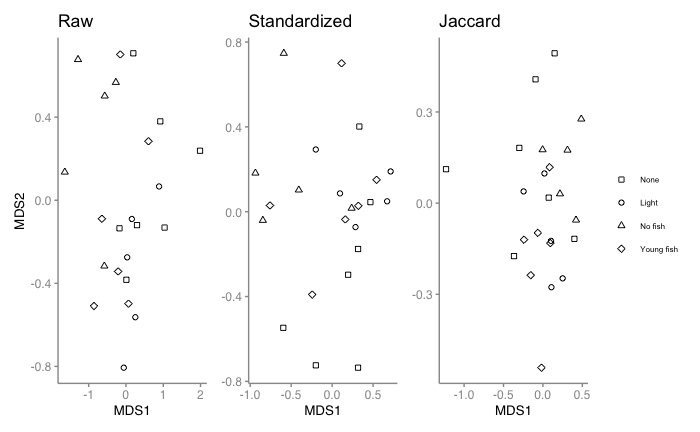

```r
p4
```

Colour version

```r
p1a<-ggplot(data=a, aes(x=MDS1, y=MDS2, color=manag, ) )+
  geom_point()+
  labs(y="MDS2", x="MDS1", title="Raw")+
  scale_color_uchicago(
                      breaks=br,
                     labels=la,
                     guide =
                         guide_legend(label.theme = element_text(size=6),
                                    title=NULL)
                     )+
  theme_qk()
p2a<-ggplot(data=as, aes(x=MDS1, y=MDS2, color=manag, ) )+
  geom_point()+
  labs(y=NULL, x="MDS1", title="Standardized")+
  scale_color_uchicago(
                     name="Management",
                     breaks=br,
                     labels=la,
                     guide =
                         guide_legend(label.theme = element_text(size=6),
                                    title=NULL)
                     )+
  theme_qk()
p3a<-ggplot(data=aj, aes(x=MDS1, y=MDS2, color=manag, ) )+
  geom_point()+
  labs(y=NULL, x="MDS1", title="Jacard")+
  scale_color_uchicago(
                      breaks=br,
                     labels=la,
                     guide =
                         guide_legend(label.theme = element_text(size=6),
                                    title=NULL)
                     )+
  theme_qk()
p4a<-p1a+p2a+p3a+plot_layout(guides='collect')&theme(axis.text=element_blank())
```

|  | t | l | b | r |
| --- | --- | --- | --- | --- |
| 1: | 1 | 1 | 1 | 1 |
| 2: | 1 | 2 | 1 | 2 |
| 3: | 1 | 3 | 1 | 3 |

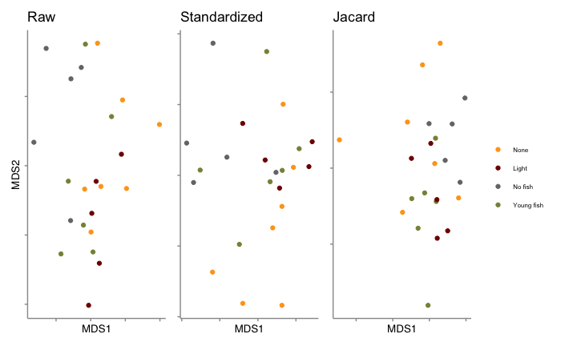

```r
p4a
```